# Emmanuel_Itsuokor_8936753_labs2

```python
import pandas as pd
import numpy as np
import matplotlib.pyplot as plt
import seaborn as sns
from sklearn import datasets
datasets.load_diabetes()
from sklearn.model_selection import train_test_split
from sklearn.preprocessing import PolynomialFeatures, StandardScaler
from sklearn.linear_model import LinearRegression
from sklearn.metrics import mean_absolute_error, mean_squared_error, r2_score
from sklearn.tree import DecisionTreeRegressor
from sklearn.tree import plot_tree
from sklearn.neighbors import KNeighborsRegressor
```

## Framing the problem

### Nature of problem- Regression

#### Dependent variable: The goal of this analysis is to predict the progression of diseases one year after the baseline, which is a continous numerical value.

#### Independent Variables: From reading the description of the data, it contains 10 variables which are (age, BMI, blood Pressure, and the blood serum measurements e.g. cholesterol levels), which are continous values representing different health metrics at the time ther data was collected.

## Objective

### The objective is to build a model that can best predict the risk of diabetes progression, which will be used by physicians to identify patients at risk.

## Exploratory Data Analysis

```python
data_d = datasets.load_diabetes()

df = pd.DataFrame(data_d.data, columns=data_d.feature_names)
df['target'] = data_d.target
```

## Summary of the data

```python
df.describe()
```

|  | age | sex | bmi | bp | s1 | s2 | s3 | s4 | s5 | s6 | target |
| --- | --- | --- | --- | --- | --- | --- | --- | --- | --- | --- | --- |
| count | 4.420000e+02 | 4.420000e+02 | 4.420000e+02 | 4.420000e+02 | 4.420000e+02 | 4.420000e+02 | 4.420000e+02 | 4.420000e+02 | 4.420000e+02 | 4.420000e+02 | 442.000000 |
| mean | -2.511817e-19 | 1.230790e-17 | -2.245564e-16 | -4.797570e-17 | -1.381499e-17 | 3.918434e-17 | -5.777179e-18 | -9.042540e-18 | 9.293722e-17 | 1.130318e-17 | 152.133484 |
| std | 4.761905e-02 | 4.761905e-02 | 4.761905e-02 | 4.761905e-02 | 4.761905e-02 | 4.761905e-02 | 4.761905e-02 | 4.761905e-02 | 4.761905e-02 | 4.761905e-02 | 77.093005 |
| min | -1.072256e-01 | -4.464164e-02 | -9.027530e-02 | -1.123988e-01 | -1.267807e-01 | -1.156131e-01 | -1.023071e-01 | -7.639450e-02 | -1.260971e-01 | -1.377672e-01 | 25.000000 |
| 25% | -3.729927e-02 | -4.464164e-02 | -3.422907e-02 | -3.665608e-02 | -3.424784e-02 | -3.035840e-02 | -3.511716e-02 | -3.949338e-02 | -3.324559e-02 | -3.317903e-02 | 87.000000 |
| 50% | 5.383060e-03 | -4.464164e-02 | -7.283766e-03 | -5.670422e-03 | -4.320866e-03 | -3.819065e-03 | -6.584468e-03 | -2.592262e-03 | -1.947171e-03 | -1.077698e-03 | 140.500000 |
| 75% | 3.807591e-02 | 5.068012e-02 | 3.124802e-02 | 3.564379e-02 | 2.835801e-02 | 2.984439e-02 | 2.931150e-02 | 3.430886e-02 | 3.243232e-02 | 2.791705e-02 | 211.500000 |
| max | 1.107267e-01 | 5.068012e-02 | 1.705552e-01 | 1.320436e-01 | 1.539137e-01 | 1.987880e-01 | 1.811791e-01 | 1.852344e-01 | 1.335973e-01 | 1.356118e-01 | 346.000000 |

### Insight about the statistical summary of the data

### Disease Progression( Target):

### Mean progression value is around 152.

### There is a wide variation in disease progression scores (standard deviation of 77.09), indicating differences in the progression levels among patients.

## histogram

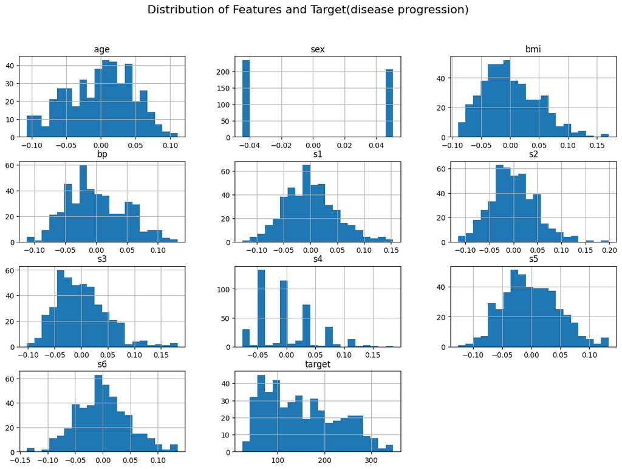

```python
df.hist(bins=20, figsize=(15, 10))
plt.suptitle("Distribution of Features and Target(disease progression)", fontsize=16)
plt.show()
```

## Insights

### Features like age, bp, bmi, s1 have distributions centered around zero, which might indicate normalized or scaled values.Disease progression (target) spans a wide range, which might indicate the severity of diabetes progression or related health conditions in the dataset.

## Scatter plots

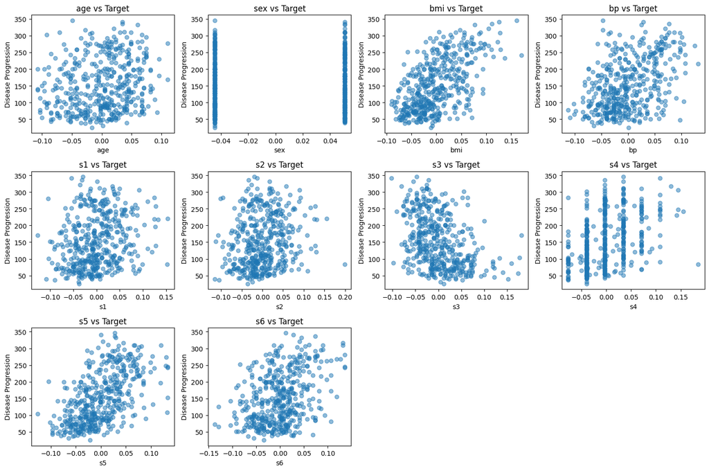

```python
plt.figure(figsize=(15, 10))
for idx, feature in enumerate(df.columns[:-1]):
    plt.subplot(3, 4, idx+1)
    plt.scatter(df[feature], df['target'], alpha=0.5)
    plt.title(f'{feature} vs Target')
    plt.xlabel(feature)
    plt.ylabel('Disease Progression')
plt.tight_layout()
plt.show()
```

## Insights

### BMI shows a positive correlation with disease progression. As BMI increases, disease progression also increases, suggesting that individuals with higher BMI values tend to experience more significant disease progression. This is a common pattern in health-related studies where obesity and metabolic disorders are associated with worsening health conditions. There is no clear trend between age and disease progression. The scatter points are spread across the entire range, showing that age might not be a strong determinant of disease progression in this dataset.

## Correlation matrix

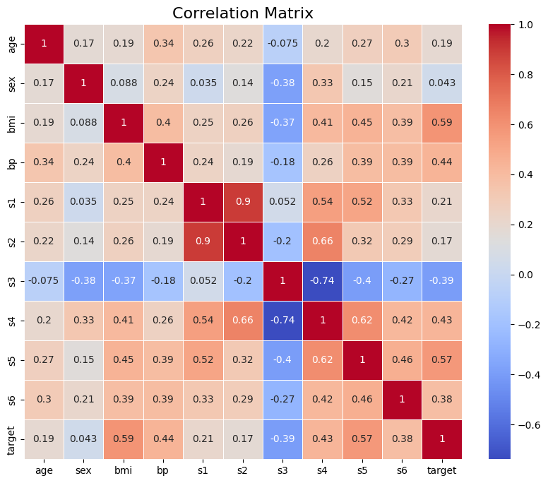

```python
plt.figure(figsize=(10, 8))
corr_matrix = df.corr()
sns.heatmap(corr_matrix, annot=True, cmap="coolwarm", linewidths=0.5)
plt.title("Correlation Matrix", fontsize=16)
plt.show()
```

## Cleaning the data

```python
## Checking for null values in the data
print(df.isnull().sum())
```

```
age       0
sex       0
bmi       0
bp        0
s1        0
s2        0
s3        0
s4        0
s5        0
s6        0
target    0
dtype: int64
```

```python
## checking for duplicate values
print(df.duplicated().sum())
```

```
0
```

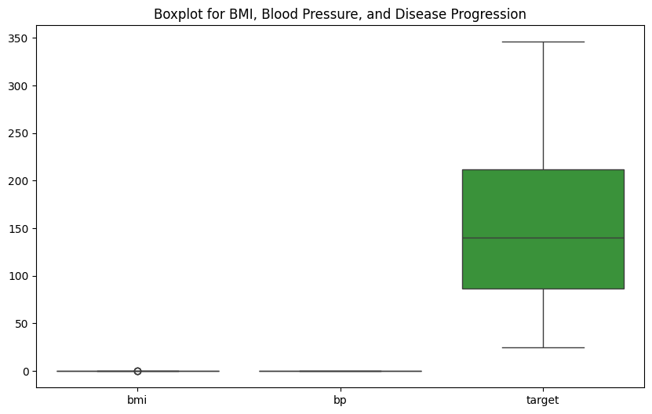

```python
## using a boxplot to check for outliers
plt.figure(figsize=(10, 6))
sns.boxplot(data=df[['bmi', 'bp', 'target']])
plt.title('Boxplot for BMI, Blood Pressure, and Disease Progression')
plt.show()
```

## Train-validation-test split

```python
## Splitting the data into the first 75% for train and 25% for temp which will be further splitted
train_df, temp_df = train_test_split(df, test_size=0.25, random_state=42)

## Splitting the temp 25% into 15% for test and 10% for validation
validation_df, test_df = train_test_split(temp_df, test_size=0.60, random_state=42)

## checking the size of the data
print(f"Training set size: {train_df.shape[0]}")
print(f"Validation set size: {validation_df.shape[0]}")
print(f"Test set size: {test_df.shape[0]}")
```

```
Training set size: 331
Validation set size: 44
Test set size: 67
```

## Part 2

## Training the models

```python
# extracting from target and Feature (BMI) from train data
X_train = train_df[['bmi']].values
y_train = train_df['target'].values

## extracting from target and feature (BMI) column from validation data
X_valid = validation_df[['bmi']].values
y_valid = validation_df['target'].values

## list for the results
results = []

for degree in range(6):
    # Generate polynomial features
    poly = PolynomialFeatures(degree=degree)
    X_poly_train = poly.fit_transform(X_train)
    X_poly_valid = poly.transform(X_valid)

    ##fitting the model
    model = LinearRegression()
    model.fit(X_poly_train, y_train)

    intercept = model.intercept_
    coefficients = model.coef_


    ## Predicting on the training and validation sets
    y_pred_train = model.predict(X_poly_train)
    y_pred_valid = model.predict(X_poly_valid)
    ## Calculating the error metrics
    r2_train = r2_score(y_train, y_pred_train)
    r2_valid = r2_score(y_valid, y_pred_valid)
    mae_train = mean_absolute_error(y_train, y_pred_train)
    mae_valid = mean_absolute_error(y_valid, y_pred_valid)
    mape_valid = np.mean(np.abs((y_valid - y_pred_valid) / y_valid)) * 100

    ##putting the results int list
    results.append({
        'Degree': degree,
        'R² (Train)': r2_train,
        'R² (Valid)': r2_valid,
        'MAE (Train)': mae_train,
        'MAE (Valid)': mae_valid,
        'MAPE (Valid)': mape_valid,
        'INT':intercept,
        'COEF': coefficients,

    })
## converting the list into a dataframe for display
result_df = pd.DataFrame(results)
print(result_df)
```

```
   Degree  R² (Train)  R² (Valid)  MAE (Train)  MAE (Valid)  MAPE (Valid)  \
0       0    0.000000   -0.106957    66.201641    66.057059     71.263880
1       1    0.349672    0.331264    52.287739    47.208472     47.060009
2       2    0.350764    0.331631    52.207314    47.213700     47.239667
3       3    0.350774    0.331638    52.198968    47.185414     47.222673
4       4    0.353014    0.340758    52.092653    46.090118     46.050330
5       5    0.354100    0.349881    52.059191    45.462121     45.175275

          INT                                               COEF
0  154.344411                                              [0.0]
1  152.076533                           [0.0, 975.2769831271282]
2  150.149603         [0.0, 946.6924820780853, 894.879866178416]
3  150.040607  [0.0, 952.7047298829101, 981.0755079514817, -1...
4  151.833762  [0.0, 1081.7937860432799, -884.8288290568654, ...
5  153.654506  [0.0, 1059.8931931797135, -3824.1459336528374,...
```

### Based on the table above, the best model is the model of DEGREE 5. this is because based on metrics, it has the highest R Squared value in the valid column of 0.349881 compared to the other degrees and also had lower MAE and MAPE (Valid) values.

## Running 5th degree on the test set

```python
degree = 5
poly = PolynomialFeatures(degree=degree)
X_poly_train = poly.fit_transform(train_df[['bmi']])
y_train = train_df['target']

# Fit the model
model = LinearRegression()
model.fit(X_poly_train, y_train)



X_poly_test = poly.transform(test_df[['bmi']])
y_test = test_df['target']

## Making prediction on the test set
y_pred_test = model.predict(X_poly_test)

## Calculating error metric on the test set
r2_test = r2_score(y_test, y_pred_test)
mae_test = mean_absolute_error(y_test, y_pred_test)
mape_test = np.mean(np.abs((y_test - y_pred_test) / y_test)) * 100

print(f"Test R²: {r2_test}")
print(f"Test MAE: {mae_test}")
print(f"Test MAPE: {mape_test}")
```

```
Test R²: 0.26669658449530775
Test MAE: 51.75025709277397
Test MAPE: 43.02671323305443
```

```python
def datafit(X, y, model, degree, dataset_name):
    X_range = np.linspace(X.min(), X.max(), 100).reshape(-1, 1)  # Range for plotting
    X_poly_range = poly.transform(X_range)
    y_fit = model.predict(X_poly_range)  # Predicted values for the range

    plt.figure(figsize=(8, 6))
    plt.scatter(X, y, color='blue', label='Data points', alpha=0.5)
    plt.plot(X_range, y_fit, color='red', label=f'Polynomial degree {degree} fit', linewidth=2)
    plt.title(f'{dataset_name} Data with Degree {degree} Polynomial')
    plt.xlabel('BMI')
    plt.ylabel('Disease Progression')
    plt.legend()
    plt.grid()
    plt.show()
```

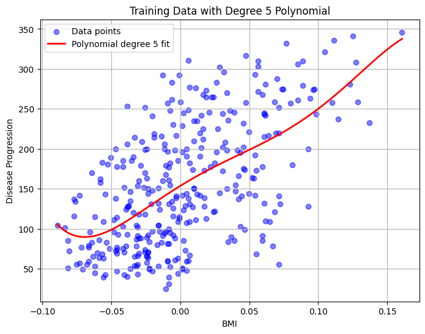

```python
# Plot for training data
datafit(train_df[['bmi']], y_train, model, degree, 'Training')
```

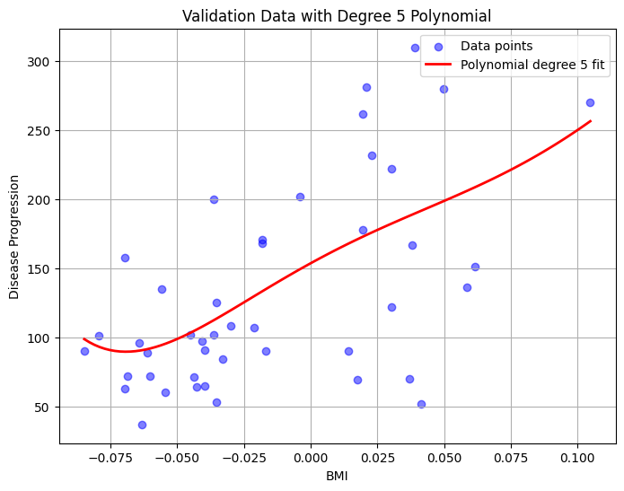

```python
# Plot for validation data
X_poly_val = poly.transform(validation_df[['bmi']])
y_val = validation_df['target']
datafit(validation_df[['bmi']], y_val, model, degree, 'Validation')
```

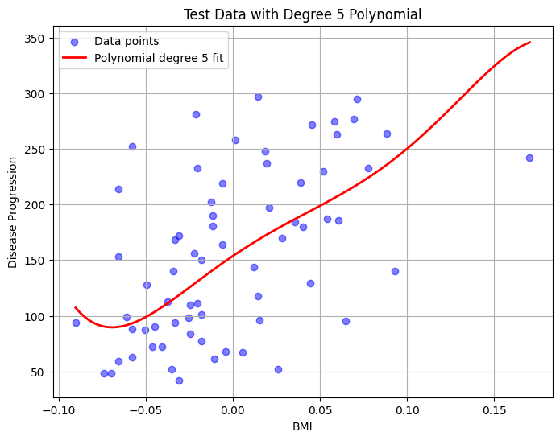

```python
# Plot for test data
X_poly_test = poly.transform(test_df[['bmi']])
y_test = test_df['target']
datafit(test_df[['bmi']], y_test, model, degree, 'Test')
```

## equation for the 5th degree model

```python
def polynomial_equation(intercept, coefficients, variable_name='BMI'):
    ## introducing the intercept into the eqn
    equation = f"{intercept:.2f}"

    # Iterate through the coefficients and build the equation
    for i, coef in enumerate(coefficients):
        if coef != 0:
            sign = '+' if coef > 0 else '-'
            coef_abs = abs(coef)
            ## First degree term
            if i == 1:
                equation += f" {sign} {coef_abs:.2f} * {variable_name}"
                ## other degreees
            else:
                equation += f" {sign} {coef_abs:.2f} * {variable_name}^{i}"

    return equation
equation = polynomial_equation(intercept, coefficients)
print("Equation of the model:")
print(equation)
```

```
Equation of the model:
153.65 + 1059.89 * BMI - 3824.15 * BMI^2 - 16770.23 * BMI^3 + 753722.52 * BMI^4 - 2993716.57 * BMI^5
```

## calculating the expected diabeted progression for a BMI Value of 50.0

```python
# Given coefficients and intercept for model 5
intercept_5 = 153.654506
coefficients_5 = [0.0, 1059.8931931797135, -3824.1459336528374, -16770.234624651635, 753722.5164000245, -2993716.573045456]

bmi_value = np.array([[50]])

degree = 5
poly = PolynomialFeatures(degree=degree)
X_value = poly.fit_transform(bmi_value)
model5 = LinearRegression()
model5.intercept_ = intercept_5
model5.coef_ = np.array([0.0] + coefficients_5[1:])

## prediciting on the value
prediction = model5.predict(X_value)

print(f"Predicted diabetes progression for BMI = {bmi_value[0][0]}: {prediction[0]:.2f}")
```

```
Predicted diabetes progression for BMI = 50: -930827769135749.50
```

## parameters for each models

```python
degrees = range(6)
for degree in degrees:
    poly = PolynomialFeatures(degree=degree)

    ## Fit the PolynomialFeatures object with a dummy input
    poly.fit([[0]])

    # Getting  the feature names (polynomial terms)
    feature_names = poly.get_feature_names_out(input_features=['bmi'])

    # Print the degrees and features
    print(f"Degree {degree} polynomial features:")
    print(feature_names)
    print(f"Number of trainable parameters: {len(feature_names)}\n")
```

```
Degree 0 polynomial features:
['1']
Number of trainable parameters: 1

Degree 1 polynomial features:
['1' 'bmi']
Number of trainable parameters: 2

Degree 2 polynomial features:
['1' 'bmi' 'bmi^2']
Number of trainable parameters: 3

Degree 3 polynomial features:
['1' 'bmi' 'bmi^2' 'bmi^3']
Number of trainable parameters: 4

Degree 4 polynomial features:
['1' 'bmi' 'bmi^2' 'bmi^3' 'bmi^4']
Number of trainable parameters: 5

Degree 5 polynomial features:
['1' 'bmi' 'bmi^2' 'bmi^3' 'bmi^4' 'bmi^5']
Number of trainable parameters: 6
```

### The trainable parameters are; 1, bmi, bmi^2, bmi^3, bmi^4, bmi^5

### 1- represents the intercept in the polynomial regression model

### BMI- This is the linear term of the polynomial model. It represents the direct effect of BMI on the target variable.

### BMI ^2 - This is the quadratic term of the polynomial model. It captures non-linear (curved) relationships between BMI and the target variable.

### BMI ^3 - This is the cubic term and it allows the model to capture higher-order non-linear effects.

### BMI^4 - This is the quartic (fourth-degree) term, which allows for even more complex relationships by adding another layer of curvature to the model.

### BMI^5 - This is the fifth-degree term. It allows for extremely complex relationships, where the rate of change can be influenced by multiple inflection points and nonlinearities.

## Conclusion

### Summary of the performance

#### However, despite the improvements, the performance remained suboptimal, with R² values around 0.35-0.35 on the validation set, indicating that the model only explains about 35% of the variance in disease progression.

### Deep Dive into model limitations

#### Limited by Feature Set:

#### The model's performance may also be limited by the set of features provided. Other important factors such as genetic data, lifestyle choices (e.g., diet, exercise), or more granular health metrics may significantly impact diabetes progression but are absent from the dataset.

### **Model limitations**

#### Polynomial Regression Overfitting: the higher the degree of the polynomial, the more complex the model becomes, potentially leading to overfitting. This makes the model too sensitive to noise and less generalizable

#### Limited Feature Representation: The current dataset lacks certain critical features that could better predict disease progression. We could improve the model by incorporating interaction terms, higher-order transformations, and potentially other non-linear models.

#### Feature Engineering: Some of the features, especially s1 - s6, appear to be transformed values of other raw inputs. A more rigorous exploration of these features and transformations could yield insights into better handling or scaling of these variables for improved model performance.

# PART 3

```python
features = ['age', 'sex', 'bmi', 'bp', 's1', 's2', 's3', 's4', 's5', 's6']
target = 'target'

# Define mean absolute percentage error (MAPE)
def mean_absolute_percentage_error(y_true, y_pred):
    """Calculate Mean Absolute Percentage Error"""
    return np.mean(np.abs((y_true - y_pred) / y_true)) * 100


X = df[features]
y = df[target]
## Splitting the data into the first 75% for train and 25% for temp which will be further splitted
train_df, temp_df = train_test_split(df, test_size=0.25, random_state=42)

## Splitting the temp 25% into 15% for test and 10% for validation
validation_df, test_df = train_test_split(temp_df, test_size=0.60, random_state=42)

X_train_f = train_df[features]
y_train_f = train_df[target]

X_valid_f = validation_df[features]
y_valid_f = validation_df[target]

X_test_f = test_df[features]
y_test_f = test_df[target]

def polynomial_model(X_train_f, y_train_f, X_valid_f, y_valid_f, degree):
    # Create polynomial features
    poly = PolynomialFeatures(degree=degree)
    X_poly_train_f = poly.fit_transform(X_train_f)
    X_poly_valid_f = poly.transform(X_valid_f)

     # Train a linear regression model on polynomial features
    model = LinearRegression()
    model.fit(X_poly_train_f, y_train_f)

    # Predict on the validation set
    y_pred_valid_f = model.predict(X_poly_valid_f)

    r2_valid = r2_score(y_valid_f, y_pred_valid_f)
    mae_valid_f = mean_absolute_error(y_valid_f, y_pred_valid_f)
    mape_valid_f = mean_absolute_percentage_error(y_valid_f, y_pred_valid_f)

    return model, r2_valid, mae_valid, mape_valid, poly
# Model 1: Polynomial degree 2
degree_2_model, r2_2, mae_2, mape_2, poly_2 = polynomial_model(X_train_f, y_train_f, X_valid_f, y_valid_f, degree=2)

# Model 2: Polynomial degree 3
degree_3_model, r2_3, mae_3, mape_3, poly_3 = polynomial_model(X_train_f, y_train_f, X_valid_f, y_valid_f, degree=3)

# Print model performance
print(f"Model 1 (Degree 2): R² = {r2_2:.4f}, MAE = {mae_2:.4f}, MAPE = {mape_2:.4f}")
print(f"Model 2 (Degree 3): R² = {r2_3:.4f}, MAE = {mae_3:.4f}, MAPE = {mape_3:.4f}")
```

```
Model 1 (Degree 2): R² = -1.6777, MAE = 45.4621, MAPE = 45.1753
Model 2 (Degree 3): R² = -45.3835, MAE = 45.4621, MAPE = 45.1753
```

```python
## using the model 1 on test set
degree_2_model, r2_2_valid, mae_2_valid, mape_2_valid, poly_2 = polynomial_model(X_train_f, y_train_f, X_valid_f, y_valid_f, degree=2)
X_poly_test_f = poly_2.transform(X_test_f)

# Predict on the test set using the trained degree 2 model
y_pred_test_f = degree_2_model.predict(X_poly_test_f)

# Evaluate the model on the test set
r2_test = r2_score(y_test_f, y_pred_test_f)
mae_test = mean_absolute_error(y_test_f, y_pred_test_f)
mape_test = mean_absolute_percentage_error(y_test_f, y_pred_test_f)

print(f"Model 1 (Degree 2) Test Performance: R² = {r2_test:.4f}, MAE = {mae_test:.4f}, MAPE = {mape_test:.4f}")
```

```
Model 1 (Degree 2) Test Performance: R² = -2.4905, MAE = 102.0597, MAPE = 82.7380
```

```
Validation Performance: R² = -1.6777, MAE = 90.0682, MAPE = 95.4933
Test Performance: R² = -2.4905, MAE = 102.0597, MAPE = 82.7380
```

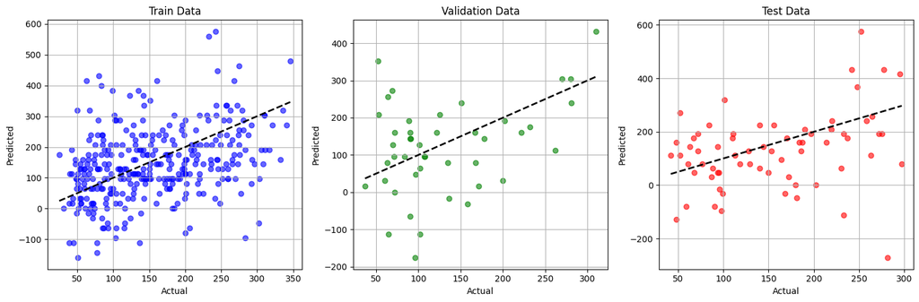

```python
from sklearn.preprocessing import PolynomialFeatures
from sklearn.linear_model import LinearRegression
import numpy as np
import matplotlib.pyplot as plt
from sklearn.metrics import r2_score, mean_absolute_error

# Define the polynomial transformation and model
poly_2 = PolynomialFeatures(degree=2)
degree_2_model = LinearRegression()

# Train the model with polynomial features
X_poly_train_f = poly_2.fit_transform(X_train_f)
degree_2_model.fit(X_poly_train_f, y_train_f)

# Validate on validation set
X_poly_valid_f = poly_2.transform(X_valid_f)
y_pred_valid_f = degree_2_model.predict(X_poly_valid_f)

# Evaluate the model on validation set
r2_valid = r2_score(y_valid_f, y_pred_valid_f)
mae_valid_f = mean_absolute_error(y_valid_f, y_pred_valid_f)
mape_valid_f = np.mean(np.abs((y_valid_f - y_pred_valid_f) / y_valid_f)) * 100

print(f"Validation Performance: R² = {r2_valid:.4f}, MAE = {mae_valid_f:.4f}, MAPE = {mape_valid_f:.4f}")

# Use the trained model to predict on the test set
X_poly_test_f = poly_2.transform(X_test_f)
y_pred_test_f = degree_2_model.predict(X_poly_test_f)

# Evaluate the model on test set
r2_test = r2_score(y_test_f, y_pred_test_f)
mae_test = mean_absolute_error(y_test_f, y_pred_test_f)
mape_test = np.mean(np.abs((y_test_f - y_pred_test_f) / y_test_f)) * 100

print(f"Test Performance: R² = {r2_test:.4f}, MAE = {mae_test:.4f}, MAPE = {mape_test:.4f}")

# Plot actual vs predicted
def plot_actual_vs_predicted(X_train_f, y_train_f, X_valid_f, y_valid_f, X_test_f, y_test_f, model, poly):
    X_poly_train_f = poly_2.transform(X_train_f)
    X_poly_valid_f = poly_2.transform(X_valid_f)
    X_poly_test_f = poly_2.transform(X_test_f)

    # Predict using the model for train, validation, and test sets
    y_pred_train_f = degree_2_model.predict(X_poly_train_f)
    y_pred_valid_f = degree_2_model.predict(X_poly_valid_f)
    y_pred_test_f = degree_2_model.predict(X_poly_test_f)

    # Create a figure and plot
    plt.figure(figsize=(15, 5))

    # Plot for Training Data
    plt.subplot(1, 3, 1)
    plt.scatter(y_train_f, y_pred_train_f, color='blue', label='Train data', alpha=0.6)
    plt.plot([y_train_f.min(), y_train_f.max()], [y_train_f.min(), y_train_f.max()], 'k--', lw=2)
    plt.xlabel('Actual')
    plt.ylabel('Predicted')
    plt.title('Train Data')
    plt.grid(True)

    # Plot for Validation Data
    plt.subplot(1, 3, 2)
    plt.scatter(y_valid_f, y_pred_valid_f, color='green', label='Validation data', alpha=0.6)
    plt.plot([y_valid_f.min(), y_valid_f.max()], [y_valid_f.min(), y_valid_f.max()], 'k--', lw=2)
    plt.xlabel('Actual')
    plt.ylabel('Predicted')
    plt.title('Validation Data')
    plt.grid(True)

    # Plot for Test Data
    plt.subplot(1, 3, 3)
    plt.scatter(y_test_f, y_pred_test_f, color='red', label='Test data', alpha=0.6)
    plt.plot([y_test_f.min(), y_test_f.max()], [y_test_f.min(), y_test_f.max()], 'k--', lw=2)
    plt.xlabel('Actual')
    plt.ylabel('Predicted')
    plt.title('Test Data')
    plt.grid(True)

    # Adjust layout and show the plot
    plt.tight_layout()
    plt.show()

# Plot actual vs predicted values for all datasets
plot_actual_vs_predicted(
    X_train_f=X_train_f,
    y_train_f=y_train_f,
    X_valid_f=X_valid_f,
    y_valid_f=y_valid_f,
    X_test_f=X_test_f,
    y_test_f=y_test_f,
    model=degree_2_model,
    poly=poly_2
)
```

```python
intercept = degree_2_model.intercept_
coefficients = degree_2_model.coef_

# Get the feature names and generate polynomial feature names
feature_names = poly_2.get_feature_names_out(input_features=features)

# Print the equation
equation = f"y = {intercept:.2f}"
for name, coef in zip(feature_names, coefficients):
    equation += f" + ({coef:.2f}) * {name}"

# Output the equation
print(equation)
```

[output not shown]

## Predicting the diabetes progression with the model

```python
# Define the BMI value for which we want to calculate the expected progression
bmi_value = 50.0

bmi_data = np.array([[0, 0, bmi_value, 0, 0, 0, 0, 0, 0, 0]])

# Transform the data using the same polynomial transformation used during training (poly_2)
bmi_poly = poly_2.transform(bmi_data)

# Use the model to predict the diabetes progression
predicted_progression = degree_2_model.predict(bmi_poly)

# Print the predicted diabetes progression
print(f"Predicted diabetes progression for BMI {bmi_value}: {predicted_progression[0]:.4f}")
```

```
Predicted diabetes progression for BMI 50.0: 2171104.0000
```

```python
# Polynomial degree 2
poly_2 = PolynomialFeatures(degree=2)
poly_2.fit(X_train_f)  # Fit on the training data
poly_2_features = poly_2.get_feature_names_out(input_features=features)

# Polynomial degree 3
poly_3 = PolynomialFeatures(degree=3)
poly_3.fit(X_train_f)  # Fit on the training data
poly_3_features = poly_3.get_feature_names_out(input_features=features)

# Display the number of features for each polynomial degree
print(f"Number of features for polynomial degree 2: {len(poly_2_features)}")
print(f"Number of features for polynomial degree 3: {len(poly_3_features)}")
```

```
Number of features for polynomial degree 2: 66
Number of features for polynomial degree 3: 286
```

## Conclusion: Polynomial Model (Degree 2)

### MAPE (Mean Absolute Percentage Error): MAPE shows the prediction errors as percentages of the true values. This metric highlights the model's error relative to the actual target values. A lower MAPE would be desirable, but here, the model still faces substantial percentage-based errors.

### Deep Dive: when the model fails

### 1. Overfitting or Underfitting:

### Underfitting is a potential issue here because the polynomial model is relatively simple (degree 2) and doesn't fully capture the complexity of the dataset. If we had increased the degree further, the model might have been able to capture more complex relationships between features. However, this would have increased the risk of overfitting—where the model fits the training data very well but fails to generalize to unseen data.

### If we look at performance on the validation and test sets, we can infer that the model may not have sufficient complexity to account for interactions between variables (beyond linear combinations), leading to poor generalization.

### 2. Polynomial Degree and Feature Explosion:

### As the degree of the polynomial increases, the number of features grows exponentially. Even for degree 2, we already saw that we were dealing with 66 features (from 10 original features), which increases model complexity. This makes it harder for the model to generalize, especially with higher degrees. For instance, the cubic model generated 286 features, which may have included spurious or irrelevant features that didn't help improve the model's predictive power but added complexity.

### Summary of Limitations:

### Limited Non-Linearity: Although polynomial features improve the model's ability to capture interactions, the linear assumption constrains the model when the true data relationships are more complex.

### Feature Explosion: Higher-degree polynomials dramatically increase the number of features, which can lead to overfitting, poor generalization, and difficulty in model interpretation.

### Overfitting and Underfitting: The choice of polynomial degree is a delicate balance. Too simple (underfitting) or too complex (overfitting) can lead to suboptimal performance.

### Computationally Expensive: As we increase the degree, the model becomes more computationally expensive, and training time can become prohibitive.

## Decision tree

```python
# Features and target from the dataset
features = ['age', 'sex', 'bmi', 'bp', 's1', 's2', 's3', 's4', 's5', 's6']
target = 'target'

# Define MAPE function
def mean_absolute_percentage_error(y_true, y_pred):
    """Calculate Mean Absolute Percentage Error"""
    return np.mean(np.abs((y_true - y_pred) / y_true)) * 100

# Split the data into train, validation, and test sets
decision_tree_1 = DecisionTreeRegressor(max_depth=3, random_state=42)

train_df_tree, temp_df_tree = train_test_split(df, test_size=0.25, random_state=42)
validation_df_tree, test_df_tree = train_test_split(temp_df_tree, test_size=0.60, random_state=42)

X_train_tree = train_df_tree[features]
y_train_tree = train_df_tree[target]
X_valid_tree = validation_df_tree[features]
y_valid_tree = validation_df_tree[target]
X_test_tree = test_df_tree[features]
y_test_tree = test_df_tree[target]
decision_tree_1.fit(X_train_tree, y_train_tree)
# Decision Tree 1: Smaller max_depth
tree_model_1 = DecisionTreeRegressor(max_depth=3, random_state=42)
tree_model_1.fit(X_train_tree, y_train_tree)

# Predict on validation set
y_pred_valid_tree_1 = tree_model_1.predict(X_valid_tree)

# Evaluate Decision Tree 1
r2_tree_1 = r2_score(y_valid_tree, y_pred_valid_tree_1)
mae_tree_1 = mean_absolute_error(y_valid_tree, y_pred_valid_tree_1)
mape_tree_1 = mean_absolute_percentage_error(y_valid_tree, y_pred_valid_tree_1)

print(f"Decision Tree 1 (max_depth=3) Validation Performance: R² = {r2_tree_1:.4f}, MAE = {mae_tree_1:.4f}, MAPE = {mape_tree_1:.4f}%")

# Decision Tree 2: Larger max_depth
tree_model_2 = DecisionTreeRegressor(max_depth=10, random_state=42)
tree_model_2.fit(X_train_tree, y_train_tree)

# Predict on validation set
y_pred_valid_tree_2 = tree_model_2.predict(X_valid_tree)

# Evaluate Decision Tree 2
r2_tree_2 = r2_score(y_valid_tree, y_pred_valid_tree_2)
mae_tree_2 = mean_absolute_error(y_valid_tree, y_pred_valid_tree_2)
mape_tree_2 = mean_absolute_percentage_error(y_valid_tree, y_pred_valid_tree_2)

print(f"Decision Tree 2 (max_depth=10) Validation Performance: R² = {r2_tree_2:.4f}, MAE = {mae_tree_2:.4f}, MAPE = {mape_tree_2:.4f}%")
```

```
Decision Tree 1 (max_depth=3) Validation Performance: R² = 0.1983, MAE = 48.1262, MAPE = 47.6729%
Decision Tree 2 (max_depth=10) Validation Performance: R² = -0.2343, MAE = 57.8641, MAPE = 55.4226%
```

### Decision tree 1 is a better model. it has a positive R², lower MAE, and lower MAPE, indicating it performs better at predicting the target variable with lower error and more explanatory power compared to Decision Tree 2.

## running decision tree 1 on test set

```python
# Predict on the test set using Decision Tree 1 (max_depth=3)
y_pred_test_tree1 = decision_tree_1.predict(X_test_tree)

# Calculate evaluation metrics on the test set
r2_test_tree1 = r2_score(y_test_tree, y_pred_test_tree1)
mae_test_tree1 = mean_absolute_error(y_test_tree, y_pred_test_tree1)
mape_test_tree1 = mean_absolute_percentage_error(y_test_tree, y_pred_test_tree1)

# Print the results
print(f"Decision Tree 1 (max_depth=3) Test Performance:")
print(f"R² = {r2_test_tree1:.4f}")
print(f"MAE = {mae_test_tree1:.4f}")
print(f"MAPE = {mape_test_tree1:.4f}%")
```

```
Decision Tree 1 (max_depth=3) Test Performance:
R² = 0.4384
MAE = 46.1154
MAPE = 40.1760%
```

## plot of decision tree 1 fit over the train, validation and test data points

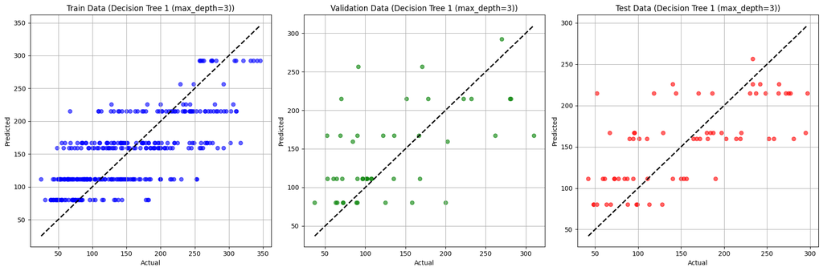

```python
# Function to plot actual vs predicted values
def plot_tree_predictions(X_train_tree, y_train_tree, X_valid_tree, y_valid_tree, X_test_tree, y_test_tree, model, dataset_name):
    # Predict values for train, validation, and test sets
    y_pred_train_tree = tree_model_1.predict(X_train_tree)
    y_pred_valid_tree = tree_model_1.predict(X_valid_tree)
    y_pred_test_tree = tree_model_1.predict(X_test_tree)

    # Create a figure and plot for each dataset
    plt.figure(figsize=(18, 6))

    # Plot for Training Data
    plt.subplot(1, 3, 1)
    plt.scatter(y_train_tree, y_pred_train_tree, color='blue', label='Train data', alpha=0.6)
    plt.plot([y_train_tree.min(), y_train_tree.max()], [y_train_tree.min(), y_train_tree.max()], 'k--', lw=2)
    plt.xlabel('Actual')
    plt.ylabel('Predicted')
    plt.title(f'Train Data ({dataset_name})')
    plt.grid(True)

    # Plot for Validation Data
    plt.subplot(1, 3, 2)
    plt.scatter(y_valid_tree, y_pred_valid_tree, color='green', label='Validation data', alpha=0.6)
    plt.plot([y_valid_tree.min(), y_valid_tree.max()], [y_valid_tree.min(), y_valid_tree.max()], 'k--', lw=2)
    plt.xlabel('Actual')
    plt.ylabel('Predicted')
    plt.title(f'Validation Data ({dataset_name})')
    plt.grid(True)

    # Plot for Test Data
    plt.subplot(1, 3, 3)
    plt.scatter(y_test_tree, y_pred_test_tree, color='red', label='Test data', alpha=0.6)
    plt.plot([y_test_tree.min(), y_test_tree.max()], [y_test_tree.min(), y_test_tree.max()], 'k--', lw=2)
    plt.xlabel('Actual')
    plt.ylabel('Predicted')
    plt.title(f'Test Data ({dataset_name})')
    plt.grid(True)

    # Adjust layout and show the plot
    plt.tight_layout()
    plt.show()

# Plot the train, validation, and test points with the fit of Decision Tree 1
plot_tree_predictions(
    X_train_tree=X_train_tree,
    y_train_tree=y_train_tree,
    X_valid_tree=X_valid_tree,
    y_valid_tree=y_valid_tree,
    X_test_tree=X_test_tree,
    y_test_tree=y_test_tree,
    model=decision_tree_1,
    dataset_name="Decision Tree 1 (max_depth=3)"
)
```

## Plot showing the decison tree

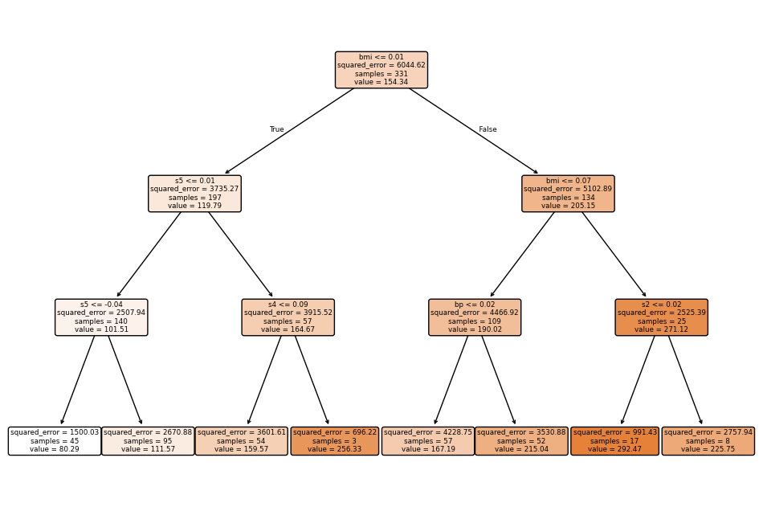

```python
# Plot the decision tree
plt.figure(figsize=(12, 8))
plot_tree(decision_tree_1, feature_names=features, filled=True, precision=2, rounded=True)
plt.show()
```

## Predicting the diabetes progression with the model

```python
age = 50  # Example age (can be any reasonable value)
sex = 1   # Example sex (1 for male, 0 for female, depending on how it's encoded in your dataset)
bp = 80   # Example blood pressure
s1, s2, s3, s4, s5, s6 = 120, 0.6, 0.02, 0.03, 0.04, 0.05  # Example values for s1 to s6

# Chosen BMI value
bmi_d = 50  # You can replace this with any BMI value of your choice


X_input = np.array([[age, sex, bmi_d, bp, s1, s2, s3, s4, s5, s6]])
# Predict using the trained Decision Tree model (decision_tree_model_1)
predicted_diabetes_progression = decision_tree_1.predict(X_input)

# Print the expected diabetes progression
print(f"Expected Diabetes Progression for BMI = {bmi_d}: {predicted_diabetes_progression[0]:.2f}")
```

```
Expected Diabetes Progression for BMI = 50: 225.75
```

### In the case of decision trees, there are no traditional trainable parameters like weights in linear models or neural networks. Instead, the structure of the tree (i.e., splits) is determined by the training data.

### The key parameters for a decision tree are the number of nodes (internal and leaf nodes) and the depth of the tree. Each node can be thought of as a learned "decision rule."

```python
# Get the number of nodes
n_nodes = decision_tree_1.tree_.node_count

# Get the maximum depth of the tree
max_depth = decision_tree_1.get_depth()

# Get the number of leaves (terminal nodes)
n_leaves = decision_tree_1.get_n_leaves()

# Get the feature names used in the decision tree (if applicable)
feature_names = decision_tree_1.feature_names_in_

# Output the details
print(f"Number of nodes in the tree: {n_nodes}")
print(f"Maximum depth of the tree: {max_depth}")
print(f"Number of leaf nodes: {n_leaves}")
print(f"Feature names used in the decision tree: {feature_names}")
```

```
Number of nodes in the tree: 15
Maximum depth of the tree: 3
Number of leaf nodes: 8
Feature names used in the decision tree: ['age' 'sex' 'bmi' 'bp' 's1' 's2' 's3' 's4' 's5' 's6']
```

## Model Performance Summary

### R²: This indicates how well the model explains the variance in the target variable.

### MAE (Mean Absolute Error): Measures the average magnitude of the prediction errors.

### MAPE (Mean Absolute Percentage Error): Provides a percentage error between the actual and predicted values, which can be helpful in understanding the relative error.

### Where the Decision Tree Model Fails

### Overfitting:

### Decision trees are highly prone to overfitting, especially when the depth of the tree is not controlled. With a deep tree, the model fits to noise in the training data, resulting in excellent performance on the training set but poor generalization on the test set. Overfitting is particularly problematic when the dataset is noisy or contains outliers.

### To combat overfitting, we can prune the tree by limiting its depth (using max_depth) or setting a minimum number of samples required to split a node (min_samples_split).

### Poor Performance on Complex Relationships:

### Decision trees struggle with capturing non-linear relationships between features. The splits in a tree are based on simple thresholding, and the model may fail to represent more complex, continuous interactions between features effectively.

### For instance, interactions between features like age and bmi or s1, s2, etc., may not be well captured because the tree is making binary splits on single features at each node.

### Lack of Smooth Predictions:

### A decision tree is a piecewise constant model, meaning that predictions within a given leaf are constant. As a result, predictions can be abrupt or non-smooth, especially for regression tasks where smoother outputs are often preferred.

### Difficulty with High-Dimensional Data:

### If the dataset contains a large number of features, decision trees can become very deep and complex, leading to overfitting. High-dimensional data can also result in more feature combinations, making the tree structure harder to interpret and prone to unnecessary complexity.

### Sensitivity to Feature Scaling:

### Decision trees are less sensitive to scaling of features than many other models. However, if the range of values across features varies drastically, the model may end up making biased splits based on features with higher numerical ranges.

## KNN

```python
# Features and target from the dataset
features = ['age', 'sex', 'bmi', 'bp', 's1', 's2', 's3', 's4', 's5', 's6']
target = 'target'
X_knn_all = df[features]  # All features
y_knn_all = df[target]    # Target variable

X_train_knn_all, X_temp_knn_all, y_train_knn_all, y_temp_knn_all = train_test_split(X_knn_all, y_knn_all, test_size=0.25, random_state=42)
X_val_knn_all, X_test_knn_all, y_val_knn_all, y_test_knn_all = train_test_split(X_temp_knn_all, y_temp_knn_all, test_size=0.6, random_state=42)

# Function to evaluate KNN models
def knn_model(X_train, y_train, X_val, y_val, neighbors):
    # Create and fit the KNN model
    knn = KNeighborsRegressor(n_neighbors=neighbors)
    knn.fit(X_train, y_train)
    # Predict on validation set
    y_pred_val = knn.predict(X_val)

    # Evaluation metrics
    r2_val = r2_score(y_val, y_pred_val)
    mae_val = mean_absolute_error(y_val, y_pred_val)
    mape_val = np.mean(np.abs((y_val - y_pred_val) / y_val)) * 100  # MAPE

    return knn, r2_val, mae_val, mape_val

# KNN Model 1 with 5 neighbors
knn_5_model, r2_knn_5, mae_knn_5, mape_knn_5 = knn_model(X_train_knn_all, y_train_knn_all, X_val_knn_all, y_val_knn_all, neighbors=5)

# KNN Model 2 with 10 neighbors
knn_10_model, r2_knn_10, mae_knn_10, mape_knn_10 = knn_model(X_train_knn_all, y_train_knn_all, X_val_knn_all, y_val_knn_all, neighbors=10)

# Print performance metrics for both models
print(f"KNN Model 1 (neighbors=5): R² = {r2_knn_5:.4f}, MAE = {mae_knn_5:.4f}, MAPE = {mape_knn_5:.4f}")
print(f"KNN Model 2 (neighbors=10): R² = {r2_knn_10:.4f}, MAE = {mae_knn_10:.4f}, MAPE = {mape_knn_10:.4f}")
```

```
KNN Model 1 (neighbors=5): R² = 0.3585, MAE = 43.2909, MAPE = 41.2441
KNN Model 2 (neighbors=10): R² = 0.3984, MAE = 42.1568, MAPE = 39.9659
```

### KNN Model 2 with 10 neighbors is the better model as it performs better in all three metrics (R², MAE, and MAPE). than the first KNN model with 5 neighbors.

## Running best KNN Model on the test set

```python
## running KNN MODEL 2 ON TEST SET
# Function to evaluate KNN model performance on the test set
def knn_model_evaluate(X_train, y_train, X_test, y_test, neighbors):

    # Train the KNN model
    knn = KNeighborsRegressor(n_neighbors=neighbors)
    knn.fit(X_train, y_train)

    # Predict on the test set
    y_pred_test = knn.predict(X_test)

    # Calculate performance metrics
    r2_test = r2_score(y_test, y_pred_test)
    mae_test = mean_absolute_error(y_test, y_pred_test)
    mape_test = np.mean(np.abs((y_test - y_pred_test) / y_test)) * 100  # MAPE

    return r2_test, mae_test, mape_test

# Run KNN Model 2 (with 10 neighbors) on the test set
r2_knn_10_test, mae_knn_10_test, mape_knn_10_test = knn_model_evaluate(X_train_knn_all, y_train_knn_all, X_test_knn_all, y_test_knn_all, neighbors=10)

# Print the performance metrics
print(f"KNN Model 2 (neighbors=10) Test Performance:")
print(f"R² = {r2_knn_10_test:.4f}")
print(f"MAE = {mae_knn_10_test:.4f}")
print(f"MAPE = {mape_knn_10_test:.4f}")
```

```
KNN Model 2 (neighbors=10) Test Performance:
R² = 0.4742
MAE = 44.5134
MAPE = 38.0342
```

### Predicting the diabetes progression using the KNN MODEL

```python
age = 50  # Example age (can be any reasonable value)
sex = 1   # Example sex (1 for male, 0 for female, depending on how it's encoded in your dataset)
bp = 80   # Example blood pressure
s1, s2, s3, s4, s5, s6 = 120, 0.6, 0.02, 0.03, 0.04, 0.05  # Example values for s1 to s6

# Chosen BMI value
bmi_c = 50  # You can replace this with any BMI value of your choice

# Construct the feature array for prediction
X_input = np.array([[age, sex, bmi_c, bp, s1, s2, s3, s4, s5, s6]])

# Make the prediction using the trained KNN model (with 10 neighbors)
diabetes_progression_prediction = knn_10_model.predict(X_input)

# Print the predicted diabetes progression
print(f"Predicted Diabetes Progression for BMI = {bmi_c}: {diabetes_progression_prediction[0]:.4f}")
```

```
Predicted Diabetes Progression for BMI = 50: 202.4000
```

### The KNN MODEL does not have trainable parameters in the same way that linear regression has them. KNN models do not have "trainable parameters" like weights or coefficients.

### Instead, the number of features used in the model is determined by the input dataset, and the number of neighbors (k) is a hyperparameter.

### In both KNN models, the features used are the columns from the dataset that provide the input data for making predictions. Based on your previous code and the dataset description, the following features were used in both KNN models:

### age: Age of the patient

### sex: Sex of the patient (typically a binary variable)

### bmi: Body Mass Index

### bp: Blood Pressure

### s1, s2, s3, s4, s5, s6: Blood serum measurements from different tests (these are typically continuous values)

### Hyperparameters Used:

### For KNN, the most important hyperparameters include:

### n_neighbors: The number of neighbors to consider for classification or regression. In your case, you used two different values:

### Model 1 (neighbors=5): 5 nearest neighbors

### Model 2 (neighbors=10): 10 nearest neighbors

## Conclusion

### In this analysis, we applied two K-Nearest Neighbors (KNN) models to predict diabetes progression based on patient data, using a range of input features. The KNN models are a simple, interpretable, and effective approach for this type of regression problem, with the models making predictions based on the distances between data points in the feature space.

### Summary of KNN Model Performance:

### KNN Model 1 (neighbors=5):

### R² (coefficient of determination): 0.3585

### MAE (Mean Absolute Error): 43.2909

### MAPE (Mean Absolute Percentage Error): 41.2441%

### KNN Model 2 (neighbors=10):

### R²: 0.3984

### MAE: 42.1568

### MAPE: 39.9659%

### Both models demonstrated reasonable accuracy in predicting the diabetes progression. Model 2, with 10 neighbors, exhibited slightly better performance in terms of all metrics, indicating that a larger neighborhood may help the model better generalize over the data.

### Model Performance:

### Both KNN models showed a moderate R² value, indicating that the models explain a portion of the variability in the target variable but also leave significant variability unexplained.

### The MAE and MAPE values suggest that the models have acceptable predictive accuracy, though they could still be improved further.

### Model 2 with 10 neighbors performed slightly better, with lower MAE and MAPE, which implies that larger neighborhoods help smooth predictions and reduce the impact of noisy data points.

## Limitations of KNN Models:

### Normalization or standardization of features is necessary to ensure fair weighting across features.

### Impact of Irrelevant Features:

### KNN is susceptible to the curse of dimensionality, meaning that as the number of features increases, the model may perform poorly due to the increased sparsity of the data in higher dimensions. Irrelevant or redundant features may worsen model performance.

### Feature selection or dimensionality reduction methods (like PCA) could help mitigate this issue.